# Basic Data Visualization with ggplot

Suppose, we want to set color. We do based on a categorical variable.

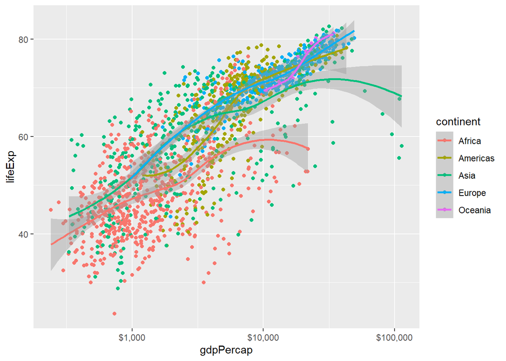

```r
p <- ggplot(data = gapminder,
            mapping = aes(x = gdpPercap,
                          y = lifeExp,
                          color = continent))  #will color based on "continent"
p + geom_point() +
    geom_smooth(method = "loess") +
    scale_x_log10(labels = scales::dollar)
```

*Mapping the continent variable to the color aesthetic,* *and correcting the error bars using the fill aesthetic.*

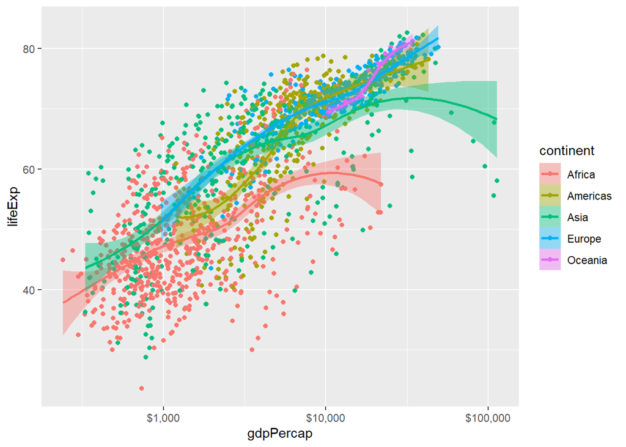

```r
p<- ggplot(data = gapminder,
            mapping = aes(x  = gdpPercap,
                          y = lifeExp,
                          color = continent,
                          fill = continent))
p + geom_point() +
    geom_smooth(method = "loess") +
    scale_x_log10(labels = scales::dollar)
```

If we want to color all points, we do the following:

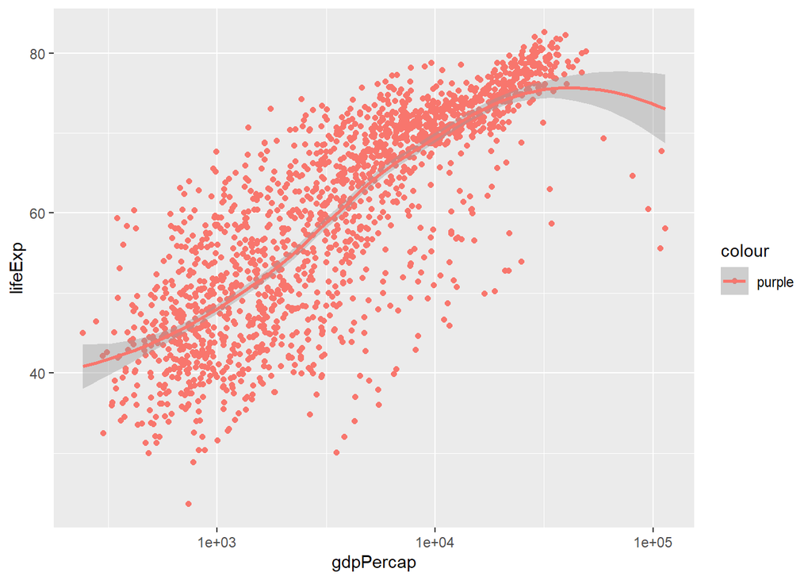

```r
p <- ggplot(data = gapminder,
            mapping = aes(x = gdpPercap,
                          y = lifeExp,
                          color = "purple")) #aes fn thinks purple as a variable
                                            #hence, it will create a new colum.
p + geom_point() +
    geom_smooth(method = "loess") +
    scale_x_log10()
```

The aes() function is for mappings only. Do not use it to change properties to a particular value. If we want to set a property, we do it in the geom_ we are using, and outside the mapping = aes(…) step. Try this:

*so for color, we use “geom_point”, not aes in mapping*

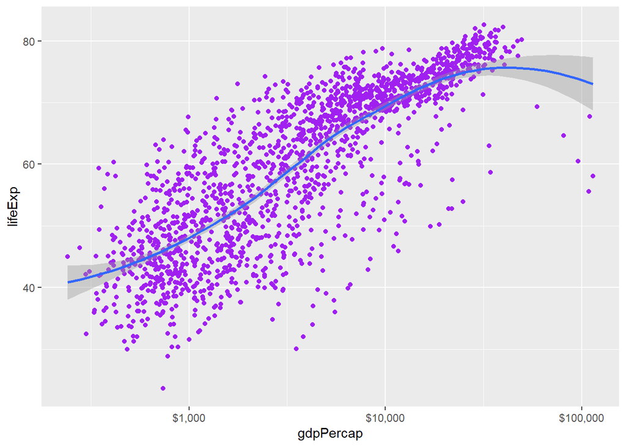

```r
 p <- ggplot(data = gapminder,
             mapping = aes(x = gdpPercap,
                           y = lifeExp))
p + geom_point(color = "purple") +
    geom_smooth(method = "loess") +
    scale_x_log10(labels = scales::dollar)
```

To set the color and size of the line, we use “geom_smooth” fn.

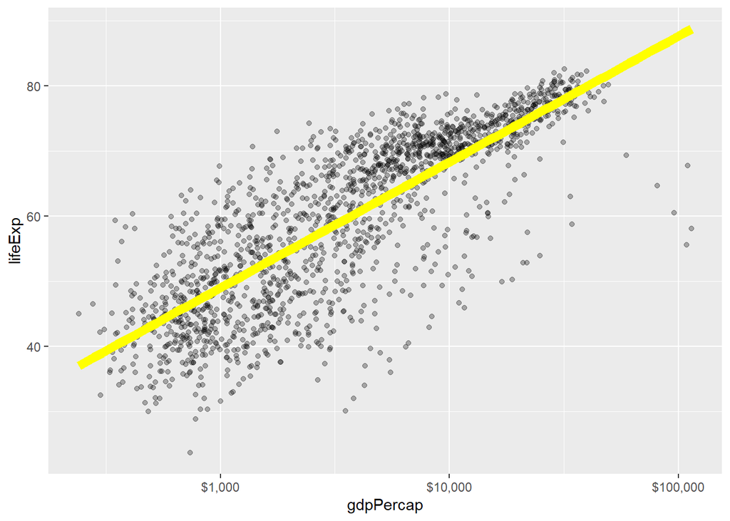

```r
p + geom_point(alpha = 0.3) + #alpha controls the opacity of all points.
  geom_smooth(color = "yellow",
              se  = F, #meaning that standard error is not known
              size = 3,
              method = "lm") +
  scale_x_log10(labels = scales::dollar)
```

Let us make the complete graph with title, subtitle, caption.

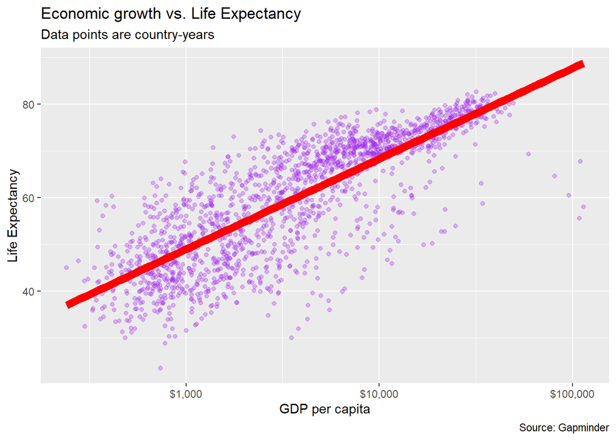

```r
 p <- ggplot(data = gapminder,
             mapping = aes(x = gdpPercap,
                           y = lifeExp))

p + geom_point(alpha = 0.3, color = "purple") +
    geom_smooth(color  = "red", size = 3, se = F, method = "lm") +
    scale_x_log10(labels = scales::dollar) +
    labs( x = "GDP per capita", y = "Life Expectancy",
          title = "Economic growth vs. Life Expectancy",
          subtitle = "Data points are country-years",
          caption = "Source: Gapminder")
```

**Aesthetics can be mapped per geom**

If we want one line, but need all points colored based on “continent”. We use “geom_point” fn.

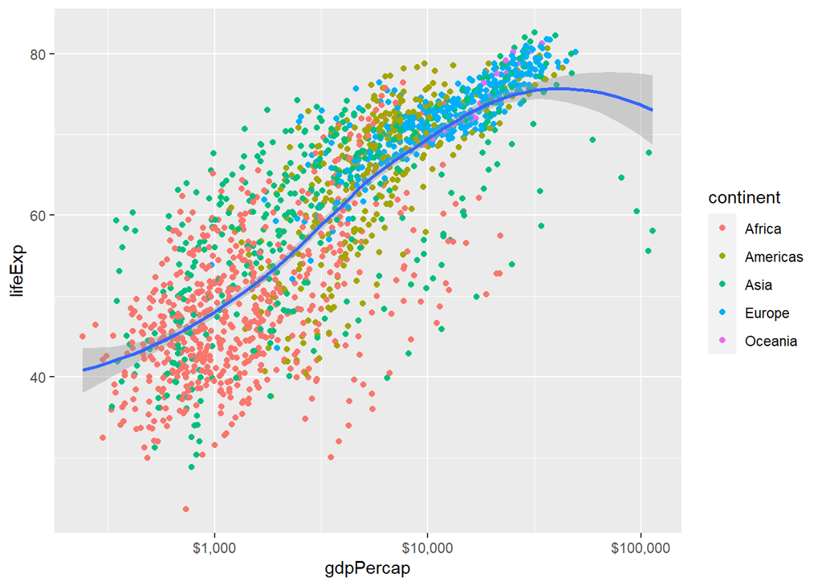

```r
p <- ggplot(data = gapminder,
            mapping = aes(x = gdpPercap,
                          y = lifeExp))
p + geom_point(mapping = aes(color = continent)) +
    geom_smooth(method = "loess") +
    scale_x_log10(labels = scales::dollar)
```

*Mapping a continuous variable to color.* We can mapped a continuous variable such as “population” as follows:

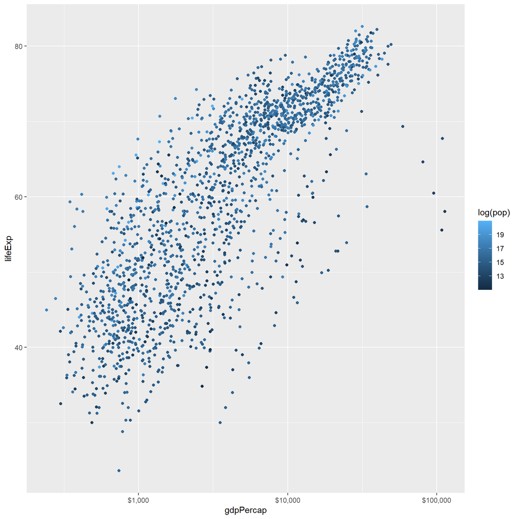

```r
p <- ggplot(data = gapminder,
            mapping = aes(x = gdpPercap,
                          y = lifeExp))
p + geom_point(mapping = aes(color = log(pop))) +
    scale_x_log10(labels = scales::dollar)
```

```r
#save the single figure
ggsave(filename = "Mapping continuousV.png") #will save the file in png
```

*Save your work*

You can also pass plot objects to ggsave(). For example, we can put our recent plot into an object called p_out and then tell ggave() that we want to save that object.

```r
p_out <- p + geom_point() +
    geom_smooth(method = "loess") +
    scale_x_log10()

ggsave("my_figure.pdf", plot = p_out)
```